# 40.242 Mathematical Finance Homework 2

##### Liu Junhua (1000378)

```python
%matplotlib inline
import csv
import urllib2
import numpy as np
from scipy.stats.mstats import kurtosis,skew
from scipy.optimize import minimize
import math
import matplotlib.mlab as mlab
import matplotlib.pyplot as plt

np.random.seed(31354)

def prepare_yahoo_data():
    url_AMZN = 'http://real-chart.finance.yahoo.com/table.csv?s=AMZN&a=01&b=1&c=2000&d=01&e=2&f=2015&g=m&ignore=.csv'
    url_DLTR = 'http://real-chart.finance.yahoo.com/table.csv?s=DLTR&a=01&b=1&c=2000&d=01&e=2&f=2015&g=m&ignore=.csv'
    url_JACK = 'http://real-chart.finance.yahoo.com/table.csv?s=JACK&a=01&b=1&c=2000&d=01&e=2&f=2015&g=m&ignore=.csv'
    url_BBBY = 'http://real-chart.finance.yahoo.com/table.csv?s=BBBY&a=01&b=1&c=2000&d=01&e=2&f=2015&g=m&ignore=.csv'
    url_GSPC = 'http://real-chart.finance.yahoo.com/table.csv?s=^GSPC&a=01&b=1&c=2000&d=01&e=2&f=2015&g=m&ignore=.csv'

    response = urllib2.urlopen(url_AMZN)
    cr = csv.reader(response)
    amzn = np.asarray([row for row in cr])

    AMZN = [float(x) for x in amzn[1:, -1]]

    response = urllib2.urlopen(url_DLTR)
    cr = csv.reader(response)
    dltr = np.asarray([row for row in cr])
    DLTR = [float(x) for x in dltr[1:, -1]]

    response = urllib2.urlopen(url_JACK)
    cr = csv.reader(response)
    jack = np.asarray([row for row in cr])
    JACK = [float(x) for x in jack[1:, -1]]

    response = urllib2.urlopen(url_BBBY)
    cr = csv.reader(response)
    bbby = np.asarray([row for row in cr])
    BBBY = [float(x) for x in bbby[1:, 6]]

    response = urllib2.urlopen(url_GSPC)
    cr = csv.reader(response)
    gspc = np.asarray([row for row in cr])
    GSPC = [float(x) for x in bbby[1:, 6]]
    return AMZN,DLTR,JACK,BBBY,GSPC
```

## Question 1. (6 points)

From http://finance.yahoo.com, download MONTHLY adjusted close prices for Amazon (AMZN), Dollar Tree (DLTR), Jack in the Box (JACK), and Bed Bath & Beyond (BBBY) during the period from Febrary-1-2000 to Febrary-2-2015 (You may also use the Bloomberg data in Trading Lab). Estimate the means and standard deviations of the monthly returns of the stocks. Estimate the covariance matrix of the monthly returns of the stocks.

```python
# get monthly adjusted close data for AMZN, DLTR, JACK, BBBY, GSPC
AMZN,DLTR,JACK,BBBY,GSPC = prepare_yahoo_data()

# Assets return
monthly_return = lambda A:[(A[i]-A[i+1])/A[i+1] for i in range(len(A)-1)]
r_AMZN = monthly_return(AMZN)
r_DLTR = monthly_return(DLTR)
r_JACK = monthly_return(JACK)
r_BBBY = monthly_return(BBBY)

cov_matrix = np.cov(np.vstack((r_AMZN,r_DLTR,r_JACK,r_BBBY)))
print
print "Answer: "
print
print "AMZN Stats: \nmean: %s, std: %s\n"%(np.mean(AMZN),np.std(AMZN, ddof =1))
print "DLTR Stats: \nmean: %s, std: %s\n"%(np.mean(DLTR),np.std(DLTR, ddof =1))
print "JACK Stats: \nmean: %s, std: %s\n"%(np.mean(JACK),np.std(JACK, ddof =1))
print "BBBY Stats: \nmean: %s, std: %s\n"%(np.mean(BBBY),np.std(BBBY, ddof =1))
print
print "Covariance matrix of the monthly returns of the stocks:"
print
for row in cov_matrix:
    print row
```

```
Answer:

AMZN Stats:
mean: 113.294198895, std: 106.122933599

DLTR Stats:
mean: 21.741160221, std: 17.633945997

JACK Stats:
mean: 24.0029281768, std: 14.663590122

BBBY Stats:
mean: 42.5852486188, std: 15.3071155774


Covariance matrix of the monthly returns of the stocks:

[ 0.02200357  0.00451233  0.00047926  0.00490165]
[ 0.00451233  0.00970237  0.00152817  0.00335945]
[ 0.00047926  0.00152817  0.00680807  0.00163685]
[ 0.00490165  0.00335945  0.00163685  0.00836393]
```

## Question 2. (6 points)

Consider a portfolio that invests 25% in Amazon, Bed Bath & Beyond, Jack in the Box, and Dollar Tree, respectively. What is the mean and standard deviation of the portfolio rate of return?

### SOLUTION

$r_p = \sum^n_i{w_ir_i}$ = 0.016

$\sigma_p = \sum^n_{i,j} w_i w_j \sigma_{ij}$ = 0.07058

```python
portf_mean = (np.mean(r_AMZN) + np.mean(r_DLTR)+ np.mean(r_JACK) + np.mean(r_BBBY))/4
portf_var = (sum([np.cov(x,y)
                 for x in [r_AMZN,r_DLTR,r_JACK,r_BBBY]
                 for y in [r_AMZN,r_DLTR,r_JACK,r_BBBY]])*0.25*0.25)[0,1]
portf_std = np.sqrt(portf_var)

print
print "Answer:"
print
print "Portfolio expected return: %s\nPortfolio std:%s"%(portf_mean,portf_std)
```

```
Answer:

Portfolio expected return: 0.0163932174945
Portfolio std:0.0705838900783
```

## Question 3. (6 points)

Consider a portfolio with 𝑤 invested in Amazon and 1 − 𝑤 invested in Bed Bath & Beyond. Plot the feasible set in a mean standard deviation diagram. Compute 𝑤 that corresponds to the minimum variance portfolio. Credit is not given to hand-plotted feasible set.

### Solution

Result as follows:

```
Answer:
```

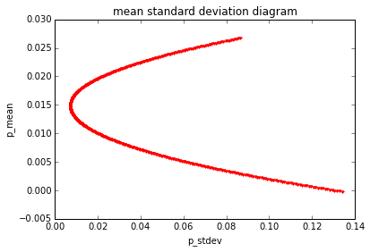

```
 Optimal w: 0.23
Corresponding risk: 0.00699
```

```python
W = np.array(range(-200,201))/100.

# monthly return for AMZN: r_AMZN
# monthly return for BBBY: r_BBBY
# std_AMZN = np.std(r_AMZN)
# std_BBBY = np.std(r_BBBY)
mean_A, mean_B = np.mean(r_AMZN), np.mean(r_BBBY)
[[var_A, cov_AB],[_,var_B]] = np.cov(r_AMZN,r_BBBY)

p_mean = [w*mean_A+(1-w)*mean_B for w in W]
p_std = [var_A*w*w + var_B*(1-w)*(1-w)+cov_AB*w*(1-w) for w in W]

[[min_w,risk]] = [[W[i],n] for (i,n) in enumerate(p_std) if n==min(p_std)]

print "\nAnswer:\n"
plt.plot(p_std, p_mean, 'r.')
plt.title("mean standard deviation diagram")
plt.xlabel("p_stdev")
plt.ylabel("p_mean")
plt.show()
print "\n Optimal w: %s"%(np.round(min_w,5))
print "Corresponding risk: %s"%(np.round(risk,5))
print
```

## Question 4. (6 points)

Assume no short selling. Find the minimum variance portfolio of the four stocks. What is the corresponding mean and standard deviation of the return of this portfolio? Find the efficient portfolio with $r_p = 1.6\%$. What is the corresponding standard deviation of the return of this portfolio?

### Solution

Setup the optimization problem as follows:

Objective: minimze $\sum_{i,j}^n w_iw_j\sigma_{i,j}$

Subject to:

1. $\sum_i^n w_i = 1$
2. $r_p > 1.6\%$ (Only applicable to the efficient portfolio with $r_p = 1.6\%$)

Solving the optimization problem, we get the answer as follows:

```python
r = [r_AMZN,r_DLTR,r_JACK,r_BBBY]
portf_mean_unweighted = np.array([np.mean(r_AMZN), np.mean(r_DLTR), np.mean(r_JACK), np.mean(r_BBBY)])

## objective function: minimize portfolio std
portf_std = lambda W:sum([W[i]*W[j]*np.cov(r[i],r[j])[0,1] for i in range(len(r)) for j in range(len(r))])

## Starting point
W = np.ones(4)/4.

## Boundary: 0 to 1
b_ = [(0.,1.) for i in range(4)]

## Constraints
c_ = ({'type':'eq', 'fun': lambda W: sum(W)-1. },
      {'type':'eq', 'fun': lambda W: sum(portf_mean_unweighted*W) - 0.016})

## Optimize result
print
print "Answer:"
print
print "\n Part 1: Minimum variance portfolio WITHOUT expected return\n"

res = minimize(portf_std,W, constraints=c_[0], method='SLSQP', bounds=b_)
W= res.x
print "Weight:%s"%W
print "Corresponding mean: %s"% sum(W * portf_mean_unweighted)
print "Corresponding std: %s"%sum([W[i]*W[j]*np.cov(r[i],r[j])[0,1] for i in range(4) for j in range(4)])

print "\n Part 2: Minimum variance portfolio with expected return of 1.6% \n"


res = minimize(portf_std,W, constraints=c_, method='SLSQP', bounds=b_)
W= res.x
print "Weight:%s"%W
print "Corresponding mean: %s"% sum(W * portf_mean_unweighted)
print "Corresponding std: %s"%sum([W[i]*W[j]*np.cov(r[i],r[j])[0,1] for i in range(4) for j in range(4)])
```

```
Answer:


 Part 1: Minimum variance portfolio WITHOUT expected return

Weight:[ 0.06809668  0.21029961  0.46345357  0.25815014]
Corresponding mean: 0.0154547766407
Corresponding std: 0.0039369523494

 Part 2: Minimum variance portfolio with expected return of 1.6%

Weight:[ 0.12612636  0.2498223   0.4715177   0.15253363]
Corresponding mean: 0.0159999999983
Corresponding std: 0.00404526983635
```

## Question 5. (6 points)

Download MONTHLY adjusted close prices for S&P500 (^GSPC) over the same period. Estimate the betas of the four stocks.

### Solution

```python
r_GSPC = monthly_return(GSPC)
beta = [(np.cov(r[i],r_GSPC)[0,1])/np.var(r_GSPC) for i in range(len(r))]

print
print "Answer: \n"
print "Estimated Beta from Calculation for AMZN, DLTR, JACK, BBBY:"
print [round(x,2) for x in beta]
print
print "Just for comparison: Beta from Yahoo finance for AMZN, DLTR, JACK, BBBY:"
print [1.27, 0.72 , 0.23, 0.69 ]
```

```
Answer:

Estimated Beta from Calculation for AMZN, DLTR, JACK, BBBY:
[0.59, 0.4, 0.2, 1.01]

Just for comparison: Beta from Yahoo finance for AMZN, DLTR, JACK, BBBY:
[1.27, 0.72, 0.23, 0.69]
```

## Question 6. (10 points)

Simulate 1000 standard normal random variables. Calculate the sample average, standard deviation, skewness, and kurtosis.

```python
def show_result(title, x):
    num_bins = 50
    n, bins, patches = plt.hist(x, num_bins, normed=1, facecolor='blue', alpha=0.5)

    # add a 'best fit' line y
    y = mlab.normpdf(bins, 0, 1)
    plt.plot(bins, y,'r')
    plt.title(title)
    plt.show()
    print "sample average: %s, standard deviation: %s"%(round(np.mean(x),3),round(np.std(x, ddof =1),3))
    print "skewness: %s, and kurtosis: %s"%(round(skew(x),3), round(kurtosis(x)+3,3))
```

#### Method 1: CLT Approximation

If $U_1, U_2, ... U_n$ are iid as U(0,1), then $Z = \frac{\sum{U_i}-{n}/{2}}{\sqrt{{n}/{12}}}$ has an approximate N(0,1) distribution.

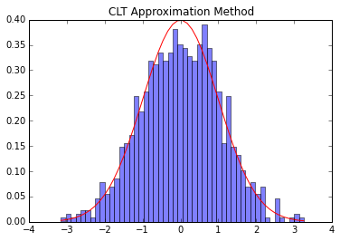

```
sample average: 0.009, standard deviation: 1.045
skewness: -0.024, and kurtosis: 2.858
```

```python
# z = f(U)
f = lambda U: (sum(U)-(len(U)/2))/np.sqrt(len(U)/12)
Z_clt = [f(np.random.uniform(size=1000)) for i in range(1000)]
show_result("CLT Approximation Method", Z_clt)
```

#### Method 2: Box-Muller Method

Generate two independent random number $U_1, U_2$ from U(0,1) distribution and return $Z_1 = \sqrt{-2lnU_1} Cos(2\pi U_2)$, $Z_2 = \sqrt{-2lnU_1} Sin(2\pi U_2)$

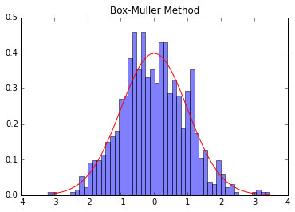

```
sample average: -0.015, standard deviation: 0.975
skewness: 0.136, and kurtosis: 3.045
```

```python
def bm(n=1000):
    r = np.sqrt(np.array(np.random.exponential(2, size=n)))
    theta =np.array(np.random.uniform(0, 2 * np.pi, size = n))
    return r * np.cos(theta)

Z_bm = bm()

show_result("Box-Muller Method",Z_bm)
```

#### Method 3: Polar Method

1.Generate two randum numbers $U_1$ and $U_2$ from U(0,1) distribution.

2.Set $V_1 = 2U_1-1$, $V_2=2U_2-1$ and $S = V_1^2 + V_2^2$

if S>1, go to step 1, else:

$Z_1 = \sqrt{\frac{(-2)\log(S)}{S}}*V_1$ and $Z_2 = \sqrt{\frac{(-2)\log(S)}{S}}*V_2$

```python
# Lazy to implement. Pass
```

#### Method 4: use numpy function

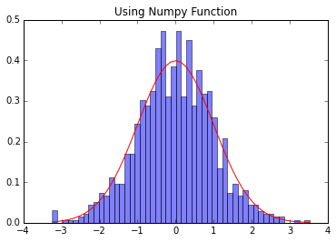

```
sample average: -0.018, standard deviation: 0.994
skewness: -0.033, and kurtosis: 3.317
```

```python
# simulate x using numpy function randn
x = np.random.randn(1000)
show_result("Using Numpy Function",x)
```